# Practical ML - Assignment

Shuo Zhao

21 December 2015

## Background

Using devices such as Jawbone Up, Nike FuelBand, and Fitbit it is now possible to collect a large amount of data about personal activity relatively inexpensively. These type of devices are part of the quantified self movement - a group of enthusiasts who take measurements about themselves regularly to improve their health, to find patterns in their behavior, or because they are tech geeks. One thing that people regularly do is quantify how much of a particular activity they do, but they rarely quantify how well they do it. In this project, your goal will be to use data from accelerometers on the belt, forearm, arm, and dumbell of 6 participants. They were asked to perform barbell lifts correctly and incorrectly in 5 different ways. More information is available from the website here: http://groupware.les.inf.puc-rio.br/har (see the section on the Weight Lifting Exercise Dataset).

## Data Sources

The training and test data for this project are available here:

- https://d396qusza40orc.cloudfront.net/predmachlearn/pml-training.csv
- https://d396qusza40orc.cloudfront.net/predmachlearn/pml-testing.csv

The data for this project come from this source: http://groupware.les.inf.puc-rio.br/har. See Reference [1].

## Data Preparation

### Data Cleaning

- Remove the first column - ‘X’

```r
train <- train[c(-1)]
```

- Remove columns which has too many NA values
  - only keep the columns which have more than 60% of non-na values

```r
csums <- colSums(!is.na(train[,-ncol(train)]))
train <- train[,csums > 0.6*nrow(train)]
```

- Identify and Remove near zero variance predictors

```r
nzvs <- nearZeroVar(train, saveMetrics = FALSE)
train <- train[,-c(nzvs)]
```

- Remove timestamp, window and user_name variables

```r
train <- train[, -which(grepl("user_name|timestamp|window", names(train)))]
```

- Partitioning Training set for CrossValidation
- split training set into cross validation traing and test set, 70% for training, 30% for testing

```r
train$classe = factor(train$classe)
inTrain <- createDataPartition(y = train$classe, p = 0.70, list=FALSE)
training <- train[inTrain, ]
testing <- train[-inTrain, ]
```

- Training Set dimension: 1402, 53
- Predictor candidates:

```
##  [1] "roll_belt"            "pitch_belt"           "yaw_belt"
##  [4] "total_accel_belt"     "gyros_belt_x"         "gyros_belt_y"
##  [7] "gyros_belt_z"         "accel_belt_x"         "accel_belt_y"
## [10] "accel_belt_z"         "magnet_belt_x"        "magnet_belt_y"
## [13] "magnet_belt_z"        "roll_arm"             "pitch_arm"
## [16] "yaw_arm"              "total_accel_arm"      "gyros_arm_x"
## [19] "gyros_arm_y"          "gyros_arm_z"          "accel_arm_x"
## [22] "accel_arm_y"          "accel_arm_z"          "magnet_arm_x"
## [25] "magnet_arm_y"         "magnet_arm_z"         "roll_dumbbell"
## [28] "pitch_dumbbell"       "yaw_dumbbell"         "total_accel_dumbbell"
## [31] "gyros_dumbbell_x"     "gyros_dumbbell_y"     "gyros_dumbbell_z"
## [34] "accel_dumbbell_x"     "accel_dumbbell_y"     "accel_dumbbell_z"
## [37] "magnet_dumbbell_x"    "magnet_dumbbell_y"    "magnet_dumbbell_z"
## [40] "roll_forearm"         "pitch_forearm"        "yaw_forearm"
## [43] "total_accel_forearm"  "gyros_forearm_x"      "gyros_forearm_y"
## [46] "gyros_forearm_z"      "accel_forearm_x"      "accel_forearm_y"
## [49] "accel_forearm_z"      "magnet_forearm_x"     "magnet_forearm_y"
## [52] "magnet_forearm_z"     "classe"
```

## Model Training and Cross Validation

- In this section, I am going to use three machine learning methods and compare them to find out the best suitable one. They are decision tree, random forest and boosting with gbm model.
- I also create training control object for cross validation. It’s going to be k-fold cross validation with k = 10.

```r
trainCtl <- trainControl(method = "cv", number = 10,
                         repeats = 2,verboseIter = TRUE)
```

### Decision Tree Model

- I use decision tree to model first because it is easy to interpret and have better performance in nonlinear settings.

```r
dt_fit <- train(classe ~ ., data = training,
                method = 'rpart', trControl = trainCtl)
```

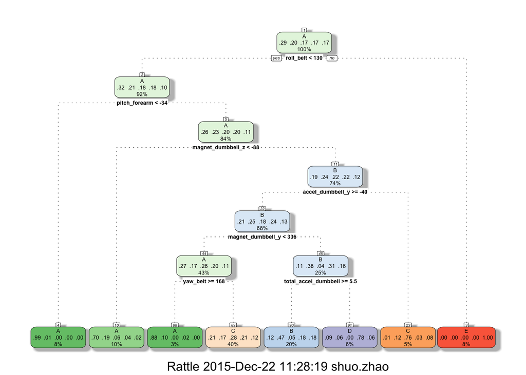

```r
pred <- predict(dt_fit, testing[, -53])
dt_cm <- confusionMatrix(pred, testing$classe)
fancyRpartPlot(dt_fit$finalModel)
```

- Decision Tree Model Summary

```
## CART
##
## 1402 samples
##   52 predictor
##    5 classes: 'A', 'B', 'C', 'D', 'E'
##
## No pre-processing
## Resampling: Cross-Validated (10 fold)
## Summary of sample sizes: 1261, 1263, 1262, 1263, 1263, 1261, ...
## Resampling results across tuning parameters:
##
##   cp          Accuracy   Kappa       Accuracy SD  Kappa SD
##   0.02825429  0.5479152  0.41754180  0.06928252   0.10714961
##   0.03834511  0.4921372  0.33588475  0.07181404   0.12424157
##   0.11503532  0.3252838  0.05023953  0.03555037   0.05612056
##
## Accuracy was used to select the optimal model using  the largest value.
## The final value used for the model was cp = 0.02825429.
```

- Decision Tree Test Result

```
##           Reference
## Prediction  A  B  C  D  E
##          A 99 13  3  4  1
##          B 20 58 10 22 21
##          C 50 45 87 51 35
##          D  7  1  0 24  0
##          E  0  0  0  0 47
```

```
##       Accuracy          Kappa  AccuracyLower  AccuracyUpper   AccuracyNull
##   5.267559e-01   4.087627e-01   4.858548e-01   5.673915e-01   2.943144e-01
## AccuracyPValue  McnemarPValue
##   1.558222e-32            NaN
```

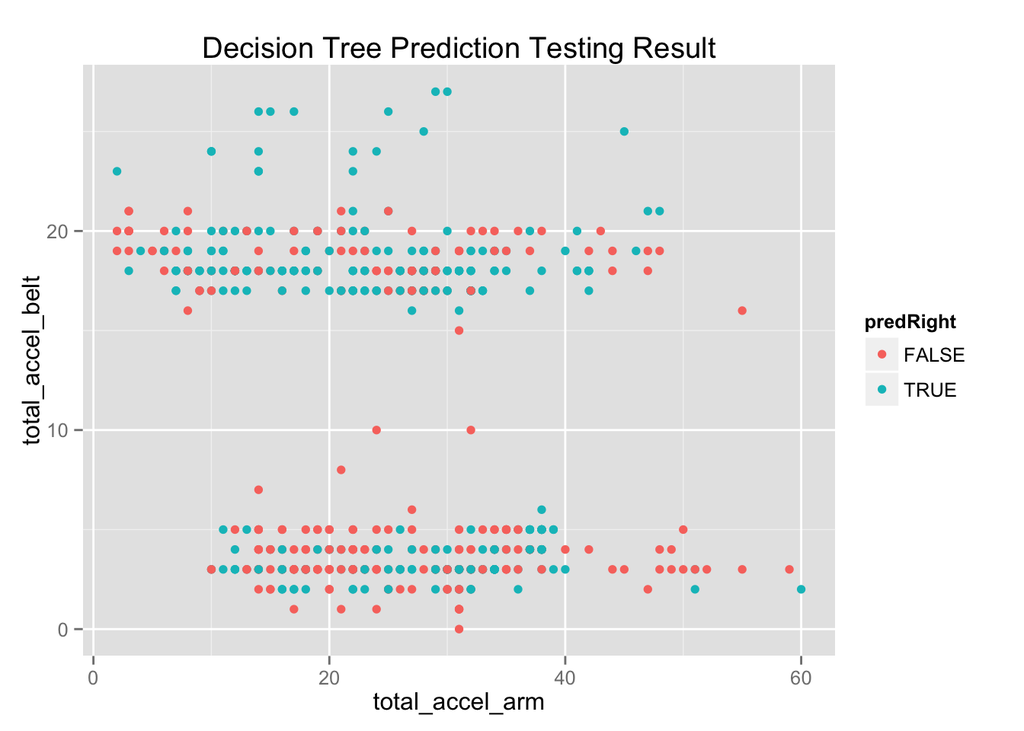

### Random Forest Model

- I use random forest as my second model due to it has great accuracy.
- Random Forest Model Summary

```
##
## Call:
##  randomForest(x = x, y = y, mtry = param$mtry, proximity = TRUE)
##                Type of random forest: classification
##                      Number of trees: 500
## No. of variables tried at each split: 27
##
##         OOB estimate of  error rate: 6.78%
## Confusion matrix:
##     A   B   C   D   E class.error
## A 408   1   0   1   1  0.00729927
## B  18 244   8   2   3  0.11272727
## C   0  12 210  11   1  0.10256410
## D   3   2  13 218   1  0.08016878
## E   3   4   5   6 227  0.07346939
```

- Random Forest Test Result

```
##           Reference
## Prediction   A   B   C   D   E
##          A 167   5   1   1   1
##          B   0 109   5   2   4
##          C   2   2  91   3   2
##          D   7   1   3  95   1
##          E   0   0   0   0  96
```

```
##       Accuracy          Kappa  AccuracyLower  AccuracyUpper   AccuracyNull
##   9.331104e-01   9.151692e-01   9.100263e-01   9.517866e-01   2.943144e-01
## AccuracyPValue  McnemarPValue
##  1.353430e-240   3.487903e-02
```

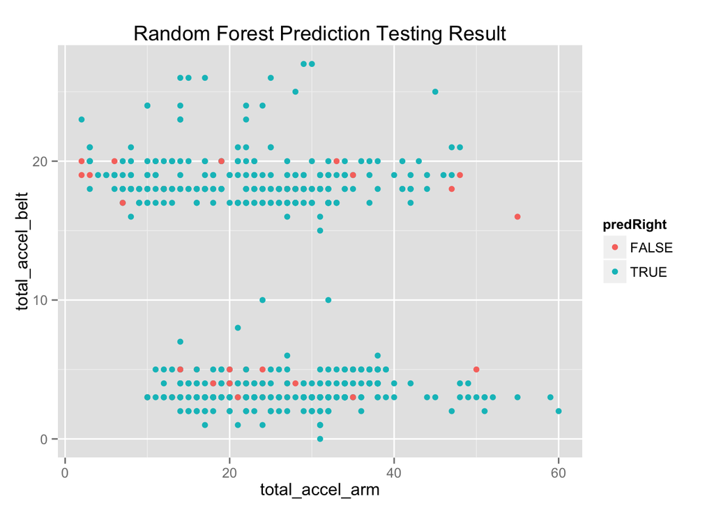

### Boosting with GBM Model

- In the third model, I use gbm model. It’s a kind of boosting with trees model.

```r
gbm_fit <- train(classe ~ ., method = "gbm", data = training,
                 verbose = FALSE, trControl = trainCtl)
pred <- predict(gbm_fit, testing[, -53])
gbm_cm <- confusionMatrix(pred, testing$classe)
```

- GBM Model Summary

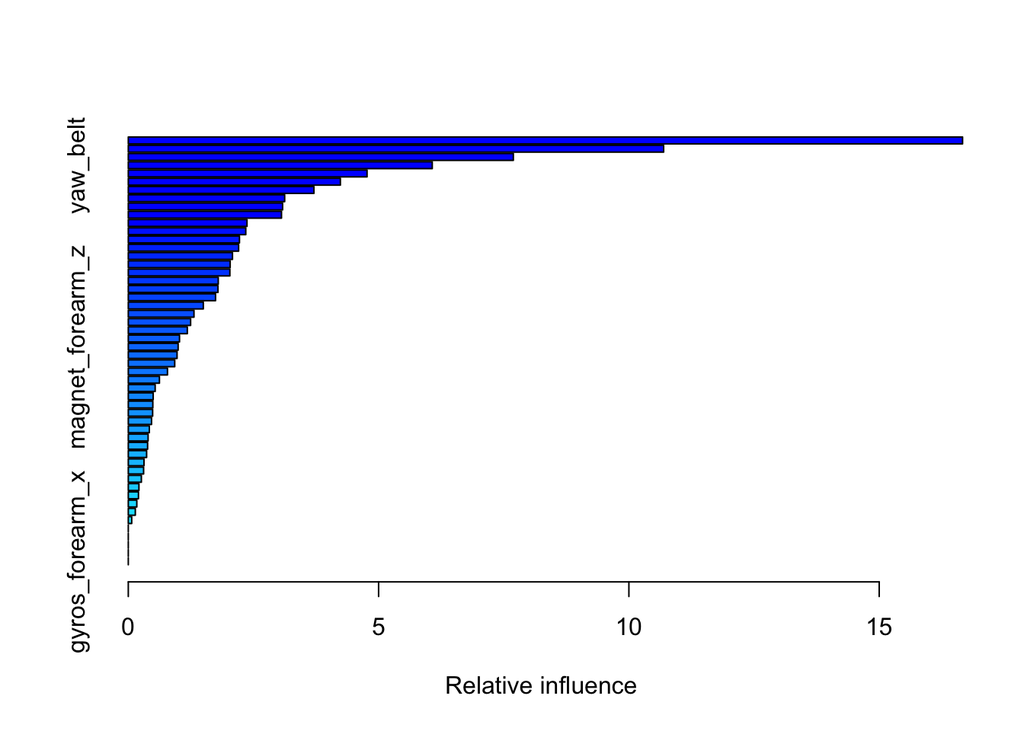

```
##                                       var     rel.inf
## roll_belt                       roll_belt 16.66534908
## pitch_forearm               pitch_forearm 10.69413171
## magnet_dumbbell_z       magnet_dumbbell_z  7.69165226
## yaw_belt                         yaw_belt  6.07189108
## magnet_dumbbell_y       magnet_dumbbell_y  4.76968502
## pitch_belt                     pitch_belt  4.23642280
## magnet_belt_z               magnet_belt_z  3.70809353
## accel_forearm_x           accel_forearm_x  3.12380901
## roll_forearm                 roll_forearm  3.08245320
## gyros_belt_z                 gyros_belt_z  3.06021128
## accel_dumbbell_x         accel_dumbbell_x  2.37113426
## magnet_belt_y               magnet_belt_y  2.34691139
## accel_dumbbell_y         accel_dumbbell_y  2.22060264
## gyros_dumbbell_y         gyros_dumbbell_y  2.20403493
## magnet_forearm_x         magnet_forearm_x  2.08095677
## yaw_arm                           yaw_arm  2.03492500
## magnet_arm_z                 magnet_arm_z  2.02925959
## yaw_dumbbell                 yaw_dumbbell  1.79719047
## roll_arm                         roll_arm  1.79134543
## accel_forearm_z           accel_forearm_z  1.74293421
## roll_dumbbell               roll_dumbbell  1.49838372
## magnet_dumbbell_x       magnet_dumbbell_x  1.31224698
## pitch_dumbbell             pitch_dumbbell  1.24476116
## gyros_arm_y                   gyros_arm_y  1.17901379
## magnet_arm_x                 magnet_arm_x  1.02304371
## magnet_forearm_z         magnet_forearm_z  0.99574502
## total_accel_dumbbell total_accel_dumbbell  0.97422571
## gyros_dumbbell_x         gyros_dumbbell_x  0.92758544
## magnet_arm_y                 magnet_arm_y  0.78252214
## magnet_belt_x               magnet_belt_x  0.62183162
## magnet_forearm_y         magnet_forearm_y  0.53702662
## gyros_forearm_z           gyros_forearm_z  0.49725122
## accel_forearm_y           accel_forearm_y  0.49009091
## gyros_forearm_y           gyros_forearm_y  0.48623876
## gyros_arm_x                   gyros_arm_x  0.46428626
## accel_dumbbell_z         accel_dumbbell_z  0.42031575
## accel_arm_y                   accel_arm_y  0.39570743
## total_accel_forearm   total_accel_forearm  0.38567160
## gyros_dumbbell_z         gyros_dumbbell_z  0.36590388
## gyros_belt_y                 gyros_belt_y  0.31385328
## accel_belt_y                 accel_belt_y  0.30582387
## pitch_arm                       pitch_arm  0.26109873
## accel_belt_z                 accel_belt_z  0.21263485
## total_accel_arm           total_accel_arm  0.20314483
## accel_arm_z                   accel_arm_z  0.17022095
## accel_arm_x                   accel_arm_x  0.14021098
## gyros_arm_z                   gyros_arm_z  0.06816709
## total_accel_belt         total_accel_belt  0.00000000
## gyros_belt_x                 gyros_belt_x  0.00000000
## accel_belt_x                 accel_belt_x  0.00000000
## yaw_forearm                   yaw_forearm  0.00000000
## gyros_forearm_x           gyros_forearm_x  0.00000000
```

- GBM Model Test Result by confusion matrix

```
##           Reference
## Prediction   A   B   C   D   E
##          A 167  10   0   3   0
##          B   1  98   4   0   7
##          C   2   3  90   3   5
##          D   5   3   5  91   1
##          E   1   3   1   4  91
```

```
##       Accuracy          Kappa  AccuracyLower  AccuracyUpper   AccuracyNull
##   8.979933e-01   8.705302e-01   8.708997e-01   9.210716e-01   2.943144e-01
## AccuracyPValue  McnemarPValue
##  6.840344e-211   2.427460e-02
```

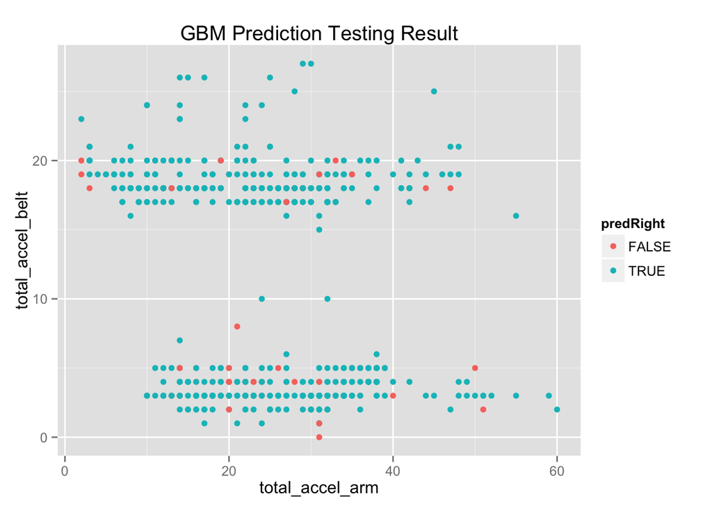

### Model Comparison

| Model | Accuracy | Kappa | CI.0.95. |
| --- | --- | --- | --- |
| Decision Tree | 0.5267559 | 0.4087627 | 0.486 ~ 0.567 |
| Random Forest | 0.9331104 | 0.9151692 | 0.91 ~ 0.952 |
| GBM | 0.8979933 | 0.8705302 | 0.871 ~ 0.921 |

- Compare all 3 models, Random Forests and GBM yielded similar results, and they both better than decision tree.

## Test Cases Submission

```r
testing_set <- read.csv('pml-testing.csv', na.strings=c("NA","#DIV/0!",""))
result <- predict(rf_fit, testing_set)
result
```

```
##  [1] B A B A A E D B A A B A B A E E A B A B
## Levels: A B C D E
```

```r
pml_write_files = function(x){
  n = length(x)
  for(i in 1:n){
    filename = paste0("problem_id_",i,".txt")
    write.table(x[i],file=filename,quote=FALSE,row.names=FALSE,col.names=FALSE)
  }
}

#pml_write_files(result)
```

## References

[1] Velloso, E.; Bulling, A.; Gellersen, H.; Ugulino, W.; Fuks, H. Qualitative Activity Recognition of Weight Lifting Exercises. Proceedings of 4th International Conference in Cooperation with SIGCHI (Augmented Human ’13) . Stuttgart, Germany: ACM SIGCHI, 2013.